# Homework 3. Clustering practice

Nisarg

2022-10-10

# Part 1. USArrests Dataset and Hierarchical Clustering (20 Points)

Consider the “USArrests” data. It is a built-in dataset you may directly get in RStudio. Perform hierarchical clustering on the observations (states) and answer the following questions.

```r
head(USArrests)
```

|  | Murder | Assault | UrbanPop | Rape |
| --- | --- | --- | --- | --- |
| Alabama | 13.2 | 236 | 58 | 21.2 |
| Alaska | 10.0 | 263 | 48 | 44.5 |
| Arizona | 8.1 | 294 | 80 | 31.0 |
| Arkansas | 8.8 | 190 | 50 | 19.5 |
| California | 9.0 | 276 | 91 | 40.6 |
| Colorado | 7.9 | 204 | 78 | 38.7 |

**Q1.1.** Using hierarchical clustering with complete linkage and Euclidean distance, cluster the states. (5 points)

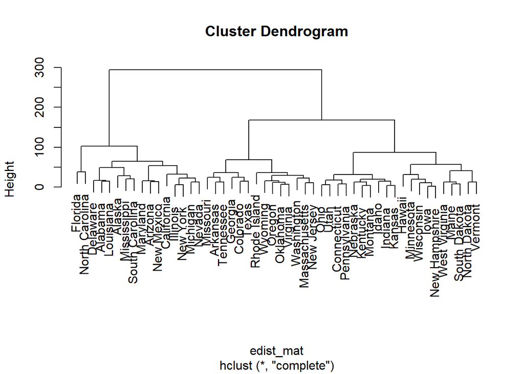

```r
set.seed(786)
us_df_sc <- as.data.frame(USArrests)
edist_mat <- dist(us_df_sc, method = 'euclidean')
hclust_com <- hclust(edist_mat, method = 'complete')
plot(hclust_com)
```

**Q1.2.** Cut the dendrogram at a height that results in three distinct clusters. Interpret the clusters. Which states belong to which clusters? (5 points)

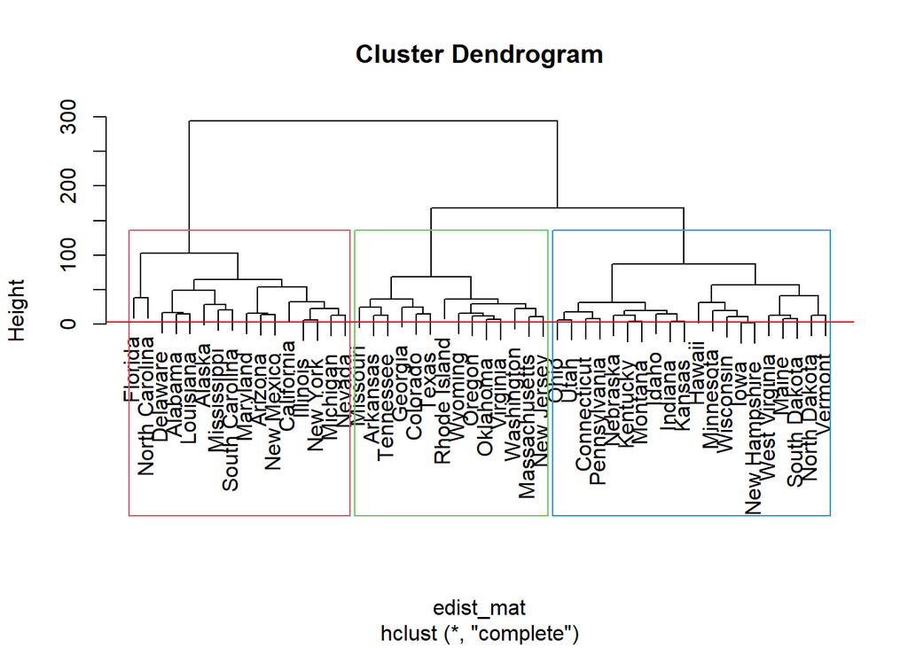

```r
plot(hclust_com)
rect.hclust(hclust_com , k = 3, border = 2:6)
abline(h = 3, col = 'red')
```

We were able to distinguish the data into three clusters as in the above 3 boxes, red, green and blue. States in: red cluster:Florida, North Carolina, Delaware, Alabama, Louisiana, Alaska, Mississippi, South Carolina, M aryland, Arizona, New Mexica, California, Illinois, New York, Michigan and Nevada. green cluster: Missouri, Arkansas, Tennessee, Georgia, Colorado, T exas, Rhode Island, Wyoming, Oregon, Oklahoma, Virginia, Washington, Massachusetts and New Je rsey blue cluster: Ohio, Utah, Connetcticut, Pennsyl vania, Nebraska, Kentucky, Montana, Idaho, Indiana, Kansas, Hawaii, Minnesota, Wiconsin, iow a, New Hampshire, West Virginia, Maine, South Dakota, North Dakota and Vermont

**Q1.3** Hierarchically cluster the states using complete linkage and Euclidean distance, after scaling the variables to have standard deviation one. (5 points)

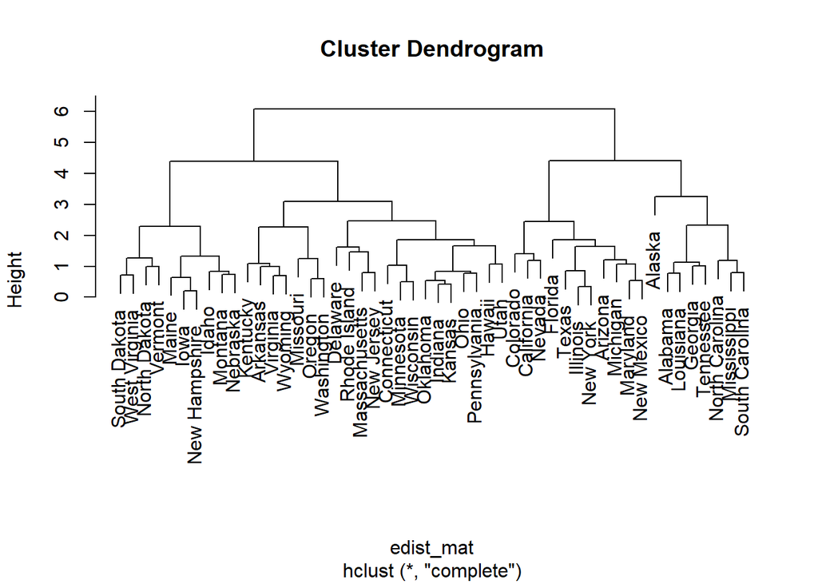

```r
us_df_sc <- as.data.frame(scale(USArrests))
edist_mat <- dist(us_df_sc, method = 'euclidean')
hclust_com <- hclust(edist_mat, method = 'complete')
plot(hclust_com)
```

```r
summary(USArrests)
```

```
##      Murder          Assault         UrbanPop          Rape
##  Min.   : 0.800   Min.   : 45.0   Min.   :32.00   Min.   : 7.30
##  1st Qu.: 4.075   1st Qu.:109.0   1st Qu.:54.50   1st Qu.:15.07
##  Median : 7.250   Median :159.0   Median :66.00   Median :20.10
##  Mean   : 7.788   Mean   :170.8   Mean   :65.54   Mean   :21.23
##  3rd Qu.:11.250   3rd Qu.:249.0   3rd Qu.:77.75   3rd Qu.:26.18
##  Max.   :17.400   Max.   :337.0   Max.   :91.00   Max.   :46.00
```

```r
summary(scale(USArrests))
```

```
##      Murder           Assault           UrbanPop             Rape
##  Min.   :-1.6044   Min.   :-1.5090   Min.   :-2.31714   Min.   :-1.4874
##  1st Qu.:-0.8525   1st Qu.:-0.7411   1st Qu.:-0.76271   1st Qu.:-0.6574
##  Median :-0.1235   Median :-0.1411   Median : 0.03178   Median :-0.1209
##  Mean   : 0.0000   Mean   : 0.0000   Mean   : 0.00000   Mean   : 0.0000
##  3rd Qu.: 0.7949   3rd Qu.: 0.9388   3rd Qu.: 0.84354   3rd Qu.: 0.5277
##  Max.   : 2.2069   Max.   : 1.9948   Max.   : 1.75892   Max.   : 2.6444
```

**Q1.4** What effect does scaling the variables have on the hierarchical clustering obtained? In your opinion, should the variables be scaled before the inter-observation dissimilarities are computed? Provide a justification for your answer. *(5 points)*

*Answer:*… Scaling affected the cluster such that the states in clusters after scaling are very different from the states present before scaling.We can see for example in the summary the minimum and maximum of murder and assult drastically changed after scaling. We can see that Assult dominates over murder in our data and scaling the values bring the features to a more comparable range.

# Part 2. Market Segmentation (80 Points)

An advertisement division of large club store needs to perform customer analysis the store customers in order to create a segmentation for more targeted marketing campaign

You task is to identify similar customers and characterize them (at least some of them). In other word perform clustering and identify customers segmentation.

This data-set is derived from https://www.kaggle.com/imakash3011/customer-personality-analysis

```
Colomns description:
People
  ID: Customer's unique identifier
  Year_Birth: Customer's birth year
  Education: Customer's education level
  Marital_Status: Customer's marital status
  Income: Customer's yearly household income
  Kidhome: Number of children in customer's household
  Teenhome: Number of teenagers in customer's household
  Dt_Customer: Date of customer's enrollment with the company
  Recency: Number of days since customer's last purchase
  Complain: 1 if the customer complained in the last 2 years, 0 otherwise

Products

  MntWines: Amount spent on wine in last 2 years
  MntFruits: Amount spent on fruits in last 2 years
  MntMeatProducts: Amount spent on meat in last 2 years
  MntFishProducts: Amount spent on fish in last 2 years
  MntSweetProducts: Amount spent on sweets in last 2 years
  MntGoldProds: Amount spent on gold in last 2 years

Place
  NumWebPurchases: Number of purchases made through the company’s website
  NumStorePurchases: Number of purchases made directly in stores
```

Assume that data was current on 2014-07-01

**Q2.1.** Read Dataset and Data Conversion to Proper Data Format *(12 points)*

Read “m_marketing_campaign.csv” using `data.table::fread` command, examine the data.

```r
# fread m_marketing_campaign.csv and save it as df
df = fread("m_marketing_campaign.csv",stringsAsFactors = FALSE)

print(c("na values:",sum(is.na(df))))
```

```
## [1] "na values:" "0"
```

```r
print(c("null values:",sum(is.null(df))))
```

```
## [1] "null values:" "0"
```

```r
head(df)
```

| ID | Year_Birth | Education | Marital_Status | Income | Kidhome | Teenhome | Dt_Customer | Recency | MntWines | MntFruits | MntMeatProducts | MntFishProducts | MntSweetProducts | MntGoldProds | NumWebPurchases | NumStorePurchases | Complain |
| --- | --- | --- | --- | --- | --- | --- | --- | --- | --- | --- | --- | --- | --- | --- | --- | --- | --- |
| 5524 | 1957 | Bachelor | Single | 58138 | 0 | 0 | 04-09-2012 | 58 | 635 | 88 | 546 | 172 | 88 | 88 | 8 | 4 | 0 |
| 2174 | 1954 | Bachelor | Single | 46344 | 1 | 1 | 08-03-2014 | 38 | 11 | 1 | 6 | 2 | 1 | 6 | 1 | 2 | 0 |
| 4141 | 1965 | Bachelor | Together | 71613 | 0 | 0 | 21-08-2013 | 26 | 426 | 49 | 127 | 111 | 21 | 42 | 8 | 10 | 0 |
| 6182 | 1984 | Bachelor | Together | 26646 | 1 | 0 | 10-02-2014 | 26 | 11 | 4 | 20 | 10 | 3 | 5 | 2 | 4 | 0 |
| 5324 | 1981 | PhD | Married | 58293 | 1 | 0 | 19-01-2014 | 94 | 173 | 43 | 118 | 46 | 27 | 15 | 5 | 6 | 0 |
| 7446 | 1967 | Master | Together | 62513 | 0 | 1 | 09-09-2013 | 16 | 520 | 42 | 98 | 0 | 42 | 14 | 6 | 10 | 0 |

```r
summary(df)
```

```
##        ID          Year_Birth    Education         Marital_Status
##  Min.   :    0   Min.   :1893   Length:2209        Length:2209
##  1st Qu.: 2826   1st Qu.:1959   Class :character   Class :character
##  Median : 5462   Median :1970   Mode  :character   Mode  :character
##  Mean   : 5592   Mean   :1969
##  3rd Qu.: 8427   3rd Qu.:1977
##  Max.   :11191   Max.   :1996
##      Income          Kidhome          Teenhome      Dt_Customer
##  Min.   :  1730   Min.   :0.0000   Min.   :0.0000   Length:2209
##  1st Qu.: 35246   1st Qu.:0.0000   1st Qu.:0.0000   Class :character
##  Median : 51390   Median :0.0000   Median :0.0000   Mode  :character
##  Mean   : 52244   Mean   :0.4418   Mean   :0.5052
##  3rd Qu.: 68627   3rd Qu.:1.0000   3rd Qu.:1.0000
##  Max.   :666666   Max.   :2.0000   Max.   :2.0000
##     Recency         MntWines        MntFruits      MntMeatProducts
##  Min.   : 0.00   Min.   :   0.0   Min.   :  0.00   Min.   :   0.0
##  1st Qu.:24.00   1st Qu.:  24.0   1st Qu.:  2.00   1st Qu.:  16.0
##  Median :49.00   Median : 174.0   Median :  8.00   Median :  68.0
##  Mean   :49.08   Mean   : 305.2   Mean   : 26.35   Mean   : 167.2
##  3rd Qu.:74.00   3rd Qu.: 505.0   3rd Qu.: 33.00   3rd Qu.: 233.0
##  Max.   :99.00   Max.   :1493.0   Max.   :199.00   Max.   :1725.0
##  MntFishProducts  MntSweetProducts  MntGoldProds    NumWebPurchases
##  Min.   :  0.00   Min.   :  0.00   Min.   :  0.00   Min.   : 0.000
##  1st Qu.:  3.00   1st Qu.:  1.00   1st Qu.:  9.00   1st Qu.: 2.000
##  Median : 12.00   Median :  8.00   Median : 24.00   Median : 4.000
##  Mean   : 37.56   Mean   : 27.07   Mean   : 43.85   Mean   : 4.082
##  3rd Qu.: 50.00   3rd Qu.: 33.00   3rd Qu.: 56.00   3rd Qu.: 6.000
##  Max.   :259.00   Max.   :262.00   Max.   :321.00   Max.   :27.000
##  NumStorePurchases    Complain
##  Min.   : 0.000    Min.   :0.000000
##  1st Qu.: 3.000    1st Qu.:0.000000
##  Median : 5.000    Median :0.000000
##  Mean   : 5.803    Mean   :0.009507
##  3rd Qu.: 8.000    3rd Qu.:0.000000
##  Max.   :13.000    Max.   :1.000000
```

```r
# Convert Year_Birth to Age (assume that current date is 2014-07-01)

df$Age = as.integer(2014 - df$Year_Birth)
present_date = as.Date("2014-07-01",format="%Y-%m-%d")


# Dt_Customer is a date (it is still character), convert it to membership days (name it MembershipDays)
# hint: note European date format, use as.Date with proper format argument

df$Dt_Customer = as.Date(df$Dt_Customer,format="%d-%m-%Y")
df$MembershipDays = as.numeric(difftime(present_date, df$Dt_Customer, "day"))

head(df)
```

| ID | Year_Birth | Education | Marital_Status | Income | Kidhome | Teenhome | Dt_Customer | Recency | MntWines | MntFruits | MntMeatProducts | MntFishProducts | MntSweetProducts | MntGoldProds | NumWebPurchases | NumStorePurchases | Complain | Age | MembershipDays |
| --- | --- | --- | --- | --- | --- | --- | --- | --- | --- | --- | --- | --- | --- | --- | --- | --- | --- | --- | --- |
| 5524 | 1957 | Bachelor | Single | 58138 | 0 | 0 | 2012-09-04 | 58 | 635 | 88 | 546 | 172 | 88 | 88 | 8 | 4 | 0 | 57 | 665 |
| 2174 | 1954 | Bachelor | Single | 46344 | 1 | 1 | 2014-03-08 | 38 | 11 | 1 | 6 | 2 | 1 | 6 | 1 | 2 | 0 | 60 | 115 |
| 4141 | 1965 | Bachelor | Together | 71613 | 0 | 0 | 2013-08-21 | 26 | 426 | 49 | 127 | 111 | 21 | 42 | 8 | 10 | 0 | 49 | 314 |
| 6182 | 1984 | Bachelor | Together | 26646 | 1 | 0 | 2014-02-10 | 26 | 11 | 4 | 20 | 10 | 3 | 5 | 2 | 4 | 0 | 30 | 141 |
| 5324 | 1981 | PhD | Married | 58293 | 1 | 0 | 2014-01-19 | 94 | 173 | 43 | 118 | 46 | 27 | 15 | 5 | 6 | 0 | 33 | 163 |
| 7446 | 1967 | Master | Together | 62513 | 0 | 1 | 2013-09-09 | 16 | 520 | 42 | 98 | 0 | 42 | 14 | 6 | 10 | 0 | 47 | 295 |

```r
# Summarize Education column (use table function)
# Lets treat Education column as ordinal categories and use simple levels for distance calculations
# Assuming following order of degrees:
#    HighSchool, Associate, Bachelor, Master, PhD
# factorize Education column (hint: use factor function with above levels)
df$Education <-factor(df$Education, order = TRUE, levels = c( "HighSchool", "Associate", "Bachelor", "Master", "PhD"))

summary(df$Education)
```

```
## HighSchool  Associate   Bachelor     Master        PhD
##         54        200       1114        363        478
```

```r
# Summarize Education column (use table function)
table(df$Education)
```

```
##
## HighSchool  Associate   Bachelor     Master        PhD
##         54        200       1114        363        478
```

```r
# Lets convert single Marital_Status categories for 5 separate binary categories
# Divorced, Married, Single, Together and Widow, the value will be 1 if customer
# is in that category and 0 if customer is not
# hint: use dummyVars from caret package, model.matrix or simple comparison (there are only 5 groups)

#dmy <- dummyVars("~ Marital_Status", data = df)
#x <- data.frame(predict(dmy, newdata = df))
#df1<-cbind(data,x)

#print(df1)
df <-df %>%
  mutate(Divorced = ifelse(Marital_Status=='Divorced', 1, 0),
         Married = ifelse(Marital_Status=='Married', 1, 0),
         Single = ifelse(Marital_Status=='Single', 1, 0),
         Together = ifelse(Marital_Status=='Together', 1, 0),
         Widow = ifelse(Marital_Status=='Widow', 1, 0))
df
```

| ID | Year_Birth | Education | Marital_Status | Income | Kidhome | Teenhome | Dt_Customer | Recency | MntWines | MntFruits | MntMeatProducts | MntFishProducts | MntSweetProducts | MntGoldProds | NumWebPurchases | NumStorePurchases | Complain | Age | MembershipDays | Divorced | Married | Single | Together | Widow |
| --- | --- | --- | --- | --- | --- | --- | --- | --- | --- | --- | --- | --- | --- | --- | --- | --- | --- | --- | --- | --- | --- | --- | --- | --- |
| 5524 | 1957 | Bachelor | Single | 58138 | 0 | 0 | 2012-09-04 | 58 | 635 | 88 | 546 | 172 | 88 | 88 | 8 | 4 | 0 | 57 | 665 | 0 | 0 | 1 | 0 | 0 |
| 2174 | 1954 | Bachelor | Single | 46344 | 1 | 1 | 2014-03-08 | 38 | 11 | 1 | 6 | 2 | 1 | 6 | 1 | 2 | 0 | 60 | 115 | 0 | 0 | 1 | 0 | 0 |
| 4141 | 1965 | Bachelor | Together | 71613 | 0 | 0 | 2013-08-21 | 26 | 426 | 49 | 127 | 111 | 21 | 42 | 8 | 10 | 0 | 49 | 314 | 0 | 0 | 0 | 1 | 0 |
| 6182 | 1984 | Bachelor | Together | 26646 | 1 | 0 | 2014-02-10 | 26 | 11 | 4 | 20 | 10 | 3 | 5 | 2 | 4 | 0 | 30 | 141 | 0 | 0 | 0 | 1 | 0 |
| 5324 | 1981 | PhD | Married | 58293 | 1 | 0 | 2014-01-19 | 94 | 173 | 43 | 118 | 46 | 27 | 15 | 5 | 6 | 0 | 33 | 163 | 0 | 1 | 0 | 0 | 0 |
| 7446 | 1967 | Master | Together | 62513 | 0 | 1 | 2013-09-09 | 16 | 520 | 42 | 98 | 0 | 42 | 14 | 6 | 10 | 0 | 47 | 295 | 0 | 0 | 0 | 1 | 0 |
| 965 | 1971 | Bachelor | Divorced | 55635 | 0 | 1 | 2012-11-13 | 34 | 235 | 65 | 164 | 50 | 49 | 27 | 7 | 7 | 0 | 43 | 595 | 1 | 0 | 0 | 0 | 0 |
| 6177 | 1985 | PhD | Married | 33454 | 1 | 0 | 2013-05-08 | 32 | 76 | 10 | 56 | 3 | 1 | 23 | 4 | 4 | 0 | 29 | 419 | 0 | 1 | 0 | 0 | 0 |
| 4855 | 1974 | PhD | Together | 30351 | 1 | 0 | 2013-06-06 | 19 | 14 | 0 | 24 | 3 | 3 | 2 | 3 | 2 | 0 | 40 | 390 | 0 | 0 | 0 | 1 | 0 |
| 5899 | 1950 | PhD | Together | 5648 | 1 | 1 | 2014-03-13 | 68 | 28 | 0 | 6 | 1 | 1 | 13 | 1 | 0 | 0 | 64 | 110 | 0 | 0 | 0 | 1 | 0 |

[output cut: 2199 more lines]

```r
# lets remove columns which we will no longer use:
# remove ID, Year_Birth, Dt_Customer, Marital_Status
# and save it as df_sel
df = select(df, -1, -2,-4, -8)


# Convert Education to integers
# hint: use as.integer function, if you use factor function earlier
# properly then HighSchool will be 1, Associate will be 2 and so on)
df$Education = as.integer(df$Education)
df
```

| Education | Income | Kidhome | Teenhome | Recency | MntWines | MntFruits | MntMeatProducts | MntFishProducts | MntSweetProducts | MntGoldProds | NumWebPurchases | NumStorePurchases | Complain | Age | MembershipDays | Divorced | Married | Single | Together | Widow |
| --- | --- | --- | --- | --- | --- | --- | --- | --- | --- | --- | --- | --- | --- | --- | --- | --- | --- | --- | --- | --- |
| 3 | 58138 | 0 | 0 | 58 | 635 | 88 | 546 | 172 | 88 | 88 | 8 | 4 | 0 | 57 | 665 | 0 | 0 | 1 | 0 | 0 |
| 3 | 46344 | 1 | 1 | 38 | 11 | 1 | 6 | 2 | 1 | 6 | 1 | 2 | 0 | 60 | 115 | 0 | 0 | 1 | 0 | 0 |
| 3 | 71613 | 0 | 0 | 26 | 426 | 49 | 127 | 111 | 21 | 42 | 8 | 10 | 0 | 49 | 314 | 0 | 0 | 0 | 1 | 0 |
| 3 | 26646 | 1 | 0 | 26 | 11 | 4 | 20 | 10 | 3 | 5 | 2 | 4 | 0 | 30 | 141 | 0 | 0 | 0 | 1 | 0 |
| 5 | 58293 | 1 | 0 | 94 | 173 | 43 | 118 | 46 | 27 | 15 | 5 | 6 | 0 | 33 | 163 | 0 | 1 | 0 | 0 | 0 |
| 4 | 62513 | 0 | 1 | 16 | 520 | 42 | 98 | 0 | 42 | 14 | 6 | 10 | 0 | 47 | 295 | 0 | 0 | 0 | 1 | 0 |
| 3 | 55635 | 0 | 1 | 34 | 235 | 65 | 164 | 50 | 49 | 27 | 7 | 7 | 0 | 43 | 595 | 1 | 0 | 0 | 0 | 0 |
| 5 | 33454 | 1 | 0 | 32 | 76 | 10 | 56 | 3 | 1 | 23 | 4 | 4 | 0 | 29 | 419 | 0 | 1 | 0 | 0 | 0 |
| 5 | 30351 | 1 | 0 | 19 | 14 | 0 | 24 | 3 | 3 | 2 | 3 | 2 | 0 | 40 | 390 | 0 | 0 | 0 | 1 | 0 |
| 5 | 5648 | 1 | 1 | 68 | 28 | 0 | 6 | 1 | 1 | 13 | 1 | 0 | 0 | 64 | 110 | 0 | 0 | 0 | 1 | 0 |

[output cut: 2199 more lines]

```r
# lets scale
# run scale function on df_sel and save it as df_scale
# that will be our scaled values which we will use for analysis
df_scale <- as.data.frame(scale(df))
df_scale
```

| Education | Income | Kidhome | Teenhome | Recency | MntWines | MntFruits | MntMeatProducts | MntFishProducts | MntSweetProducts | MntGoldProds | NumWebPurchases | NumStorePurchases | Complain | Age | MembershipDays | Divorced | Married | Single | Together | Widow |
| --- | --- | --- | --- | --- | --- | --- | --- | --- | --- | --- | --- | --- | --- | --- | --- | --- | --- | --- | --- | --- |
| -0.4555844 | 0.233903916 | -0.8227362 | -0.9281454 | 0.308273215 | 0.9766565922 | 1.548865934 | 1.6879548974 | 2.463060735 | 1.481888649 | 0.854827036 | 1.43049407 | -0.5538715 | -0.09794622 | 0.98536293 | 1.530050846 | -0.3424856 | -0.7959829 | 1.9205079 | -0.5916806 | -0.1887179 |
| -0.4555844 | -0.234140265 | 1.0393789 | 0.9090170 | -0.382616586 | -0.8711997030 | -0.637055768 | -0.7180698965 | -0.651417093 | -0.634215838 | -0.732673832 | -1.12522283 | -1.1683880 | -0.09794622 | 1.23576558 | -1.188907160 | -0.3424856 | -0.7959829 | 1.9205079 | -0.5916806 | -0.1887179 |
| -0.4555844 | 0.768658481 | -0.8227362 | -0.9281454 | -0.797150466 | 0.3577431856 | 0.568969999 | -0.1789421186 | 1.345512808 | -0.147755036 | -0.035722231 | 1.43049407 | 1.2896778 | -0.09794622 | 0.31762255 | -0.205138718 | -0.3424856 | -0.7959829 | -0.5204599 | 1.6893359 | -0.1887179 |
| -0.4555844 | -1.015854211 | 1.0393789 | -0.9281454 | -0.797150466 | -0.8711997030 | -0.561679157 | -0.6556914759 | -0.504853431 | -0.585569758 | -0.752033598 | -0.76012042 | -0.5538715 | -0.09794622 | -1.26826086 | -1.060374600 | -0.3424856 | -0.7959829 | -0.5204599 | 1.6893359 | -0.1887179 |
| 1.5352880 | 0.240055082 | 1.0393789 | -0.9281454 | 1.551874857 | -0.3914677802 | 0.418216778 | -0.2190425319 | 0.154683051 | -0.001816796 | -0.558435932 | 0.33518682 | 0.0606449 | -0.09794622 | -1.01785822 | -0.951616280 | -0.3424856 | 1.2557397 | -0.5204599 | -0.5916806 | -0.1887179 |
| 0.5398518 | 0.407525528 | -0.8227362 | 0.9090170 | -1.142595367 | 0.6361061531 | 0.393091241 | -0.3081545613 | -0.688058009 | 0.363028806 | -0.577795698 | 0.70028924 | 1.2896778 | -0.09794622 | 0.15068745 | -0.299066358 | -0.3424856 | -0.7959829 | -0.5204599 | 1.6893359 | -0.1887179 |
| -0.4555844 | 0.134572511 | -0.8227362 | 0.9090170 | -0.520794546 | -0.2078666740 | 0.970978588 | -0.0140848642 | 0.227964882 | 0.533290086 | -0.326118731 | 1.06539165 | 0.3679031 | -0.09794622 | -0.18318274 | 1.184001645 | 2.9185089 | -0.7959829 | -0.5204599 | -0.5916806 | -0.1887179 |
| 1.5352880 | -0.745679140 | 1.0393789 | -0.9281454 | -0.589883526 | -0.6787146723 | -0.410925936 | -0.4952898230 | -0.633096635 | -0.634215838 | -0.403557798 | -0.02991559 | -0.5538715 | -0.09794622 | -1.35172841 | 0.313935083 | -0.3424856 | 1.2557397 | -0.5204599 | -0.5916806 | -0.1887179 |
| 1.5352880 | -0.868821509 | 1.0393789 | -0.9281454 | -1.038961897 | -0.8623157785 | -0.662181304 | -0.6378690701 | -0.633096635 | -0.585569758 | -0.810112898 | -0.39501800 | -1.1683880 | -0.09794622 | -0.43358538 | 0.170571843 | -0.3424856 | -0.7959829 | -0.5204599 | 1.6893359 | -0.1887179 |
| 1.5352880 | -1.849158579 | 1.0393789 | 0.9090170 | 0.653718116 | -0.8208574642 | -0.662181304 | -0.7180698965 | -0.669737551 | -0.634215838 | -0.597155465 | -1.12522283 | -1.7829044 | -0.09794622 | 1.56963577 | -1.213624961 | -0.3424856 | -0.7959829 | -0.5204599 | 1.6893359 | -0.1887179 |

[output cut: 2199 more lines]

## PCA

**Q2.2.** Run PCA *(12 points)*

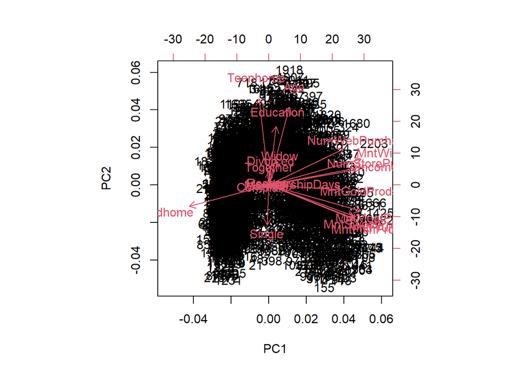

```r
# Run PCA on df_scale, make biplot and scree plot/percentage variance explained plot
# save as pc_out, we will use pc_out$x[,1] and pc_out$x[,2] later for plotting
pc_out <- prcomp(df_scale)
biplot(pc_out)#(pc_out) %>% ggplotly()
```

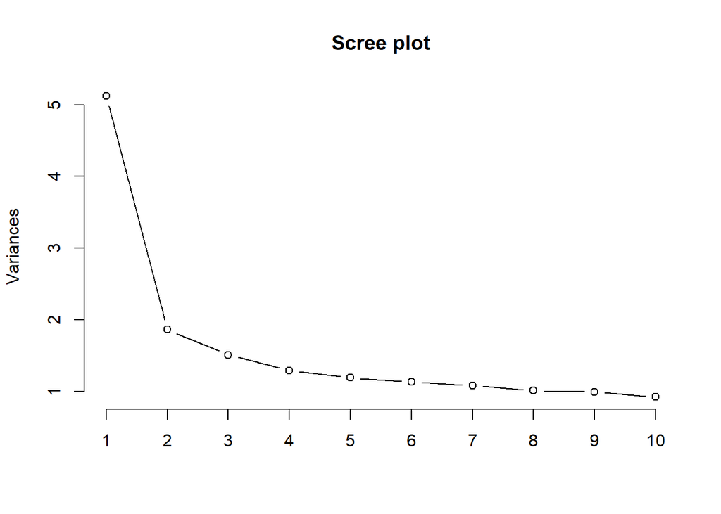

```r
screeplot(pc_out, type = "line", main = "Scree plot")
```

**Q2.3** Comment on observation (any visible distinct clusters?) *(4 points)*

1st PC has highest variance more than two times larger than second, however it is still around 25%. Second and higher PC has PVE less than 10%. Slow grow in cumulative PVE shows that large number of features is needed.

May be two clusters?

Cumulative PVE of first and second PCA is only 30%. This tells us that we need more iterations of PCA to be able to explain more variance.From the biplot we can see that we can create many more clusters to divide the data.

## Cluster with K-Means

In questions Q2.4 to Q2.9 use K-Means method for clustering

### Selecting Number of Clusters

**Q2.4** Select optimal number of clusters using elbow method. *(6 points)*

```r
#compute from k=2 to k=20
k.max <- 20
data <- df_scale
wss <- sapply(1:k.max,
              function(k){kmeans(data, k, nstart=50,iter.max = 20 )$tot.withinss})
wss
```

```
##  [1] 46368.00 37479.33 34778.20 32638.74 31123.27 29518.03 27991.88 27065.93
##  [9] 25035.86 24122.99 23322.89 22729.60 22166.47 21640.18 21266.80 20953.10
## [17] 20580.06 20274.21 19864.48 19528.35
```

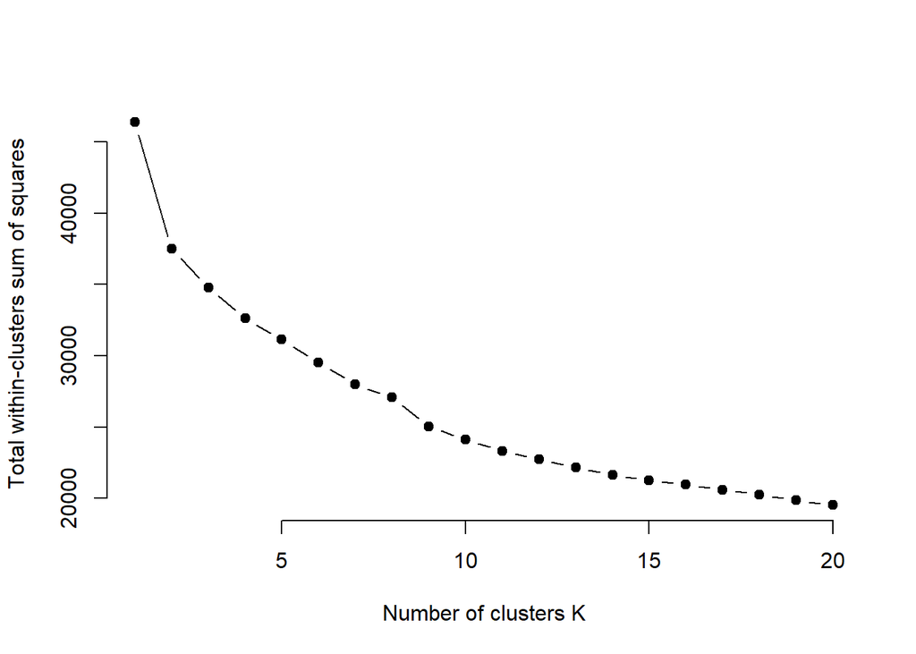

```r
plot(1:k.max, wss,
     type="b", pch = 19, frame = FALSE,
     xlab="Number of clusters K",
     ylab="Total within-clusters sum of squares")
```

**Q2.5** Select optimal number of clusters using Gap Statistic.*(6 points)*

```r
gap_kmeans <- clusGap(df_scale, kmeans, nstart = 20, K.max = 10, B = 100)
```

[output not shown]

[output cut: 12 more lines]

[output not shown]

[output not shown]

[output cut: 56 more lines]

[output not shown]

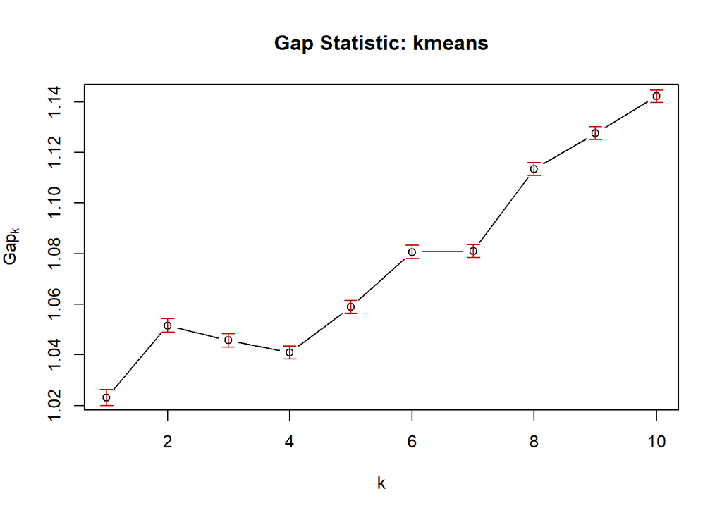

```r
plot(gap_kmeans, main = "Gap Statistic: kmeans")
```

**Q2.6** Select optimal number of clusters using Silhouette method.*(6 points)*

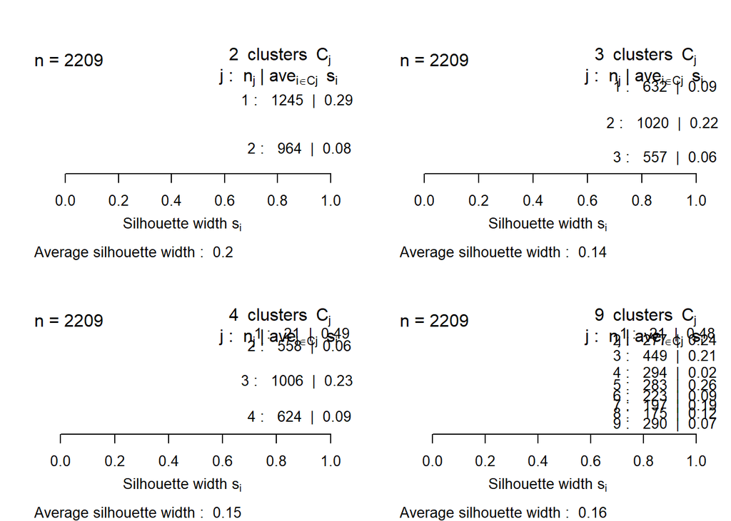

```r
par(mar = c(5, 2, 4, 2), mfrow=c(2,2))
for(k in c(2,3,4,9)) {
  kmeans_cluster <- kmeans(df_scale, k, nstart=20)
  si <- silhouette(kmeans_cluster$cluster, dist = dist(df_scale))
  plot(si,main="")
}
```

```r
par(mar = c(1, 1, 1, 1), mfrow=c(1,1))
```

**Q2.7** Which k will you choose based on elbow, gap statistics and silhuettes as well as clustering task (market segmentation for advertisement purposes)?*(4 points)* In elbow plot k =2 is optimal In Gap statistics k = 2 is optimal In Silhoutte plot k = 2 is optimal Hence, the optimal number for the number of clusters is k=2.

## Clusters Visulalization

**Q2.8** Make k-Means clusters with selected k_kmeans (store result as km_out). Plot your k_kmeans clusters on biplot (just PC1 vs PC2) by coloring points by their cluster id.*(4 points)*

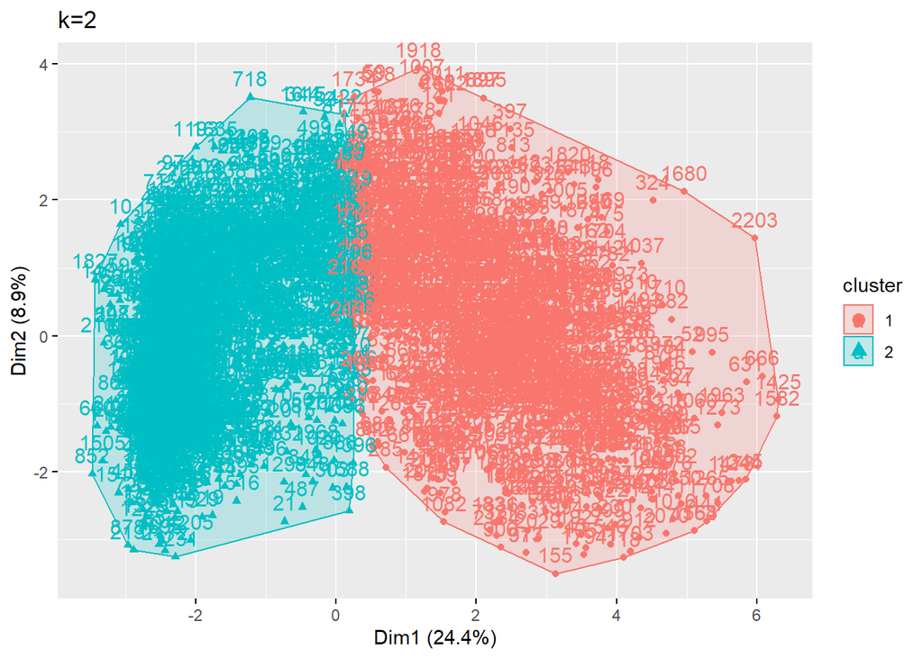

```r
km_2 <- kmeans(df_scale, 2, nstart = 25)
fviz_cluster(km_2, data = df_scale) + ggtitle("k=2")
```

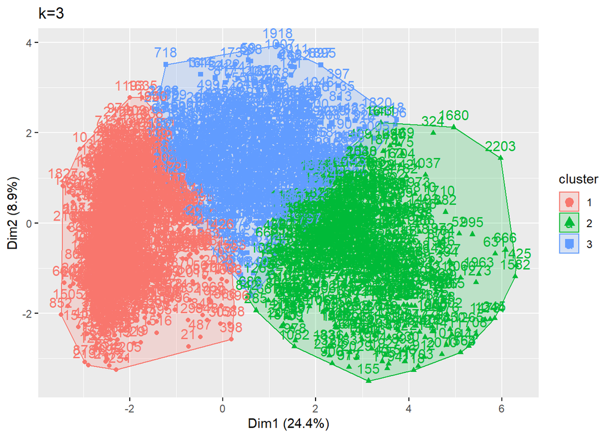

```r
km_3 <- kmeans(df_scale, 3, nstart = 25)
fviz_cluster(km_3, data = df_scale) + ggtitle("k=3")
```

**Q2.9** Do you see any grouping? Comment on you observation.*(4 points)* Yes, we are able to group the data, it is more distinct when there are only 2 clusters but grouping is valid for 3 clusters as well.

## Characterizing Cluster

**Q2.10** Perform descriptive statistics analysis on obtained cluster. Based on that does one or more group have a distinct characteristics? *(10 points)* Hint: add cluster column to original df dataframe

```r
df_scale$Cluster <- km_2$cluster
head(df_scale)
```

|  | Education | Income | Kidhome | Teenhome | Recency | MntWines | MntFruits | MntMeatProducts | MntFishProducts | MntSweetProducts | MntGoldProds | NumWebPurchases | NumStorePurchases | Complain | Age | MembershipDays | Divorced | Married | Single | Together | Widow | Cluster |
| --- | --- | --- | --- | --- | --- | --- | --- | --- | --- | --- | --- | --- | --- | --- | --- | --- | --- | --- | --- | --- | --- | --- |
| 1 | -0.4555844 | 0.2339039 | -0.8227362 | -0.9281454 | 0.3082732 | 0.9766566 | 1.5488659 | 1.6879549 | 2.4630607 | 1.481888649 | 0.85482704 | 1.4304941 | -0.5538715 | -0.09794622 | 0.9853629 | 1.5300508 | -0.3424856 | -0.7959829 | 1.9205079 | -0.5916806 | -0.1887179 | 1 |
| 2 | -0.4555844 | -0.2341403 | 1.0393789 | 0.9090170 | -0.3826166 | -0.8711997 | -0.6370558 | -0.7180699 | -0.6514171 | -0.634215838 | -0.73267383 | -1.1252228 | -1.1683880 | -0.09794622 | 1.2357656 | -1.1889072 | -0.3424856 | -0.7959829 | 1.9205079 | -0.5916806 | -0.1887179 | 2 |
| 3 | -0.4555844 | 0.7686585 | -0.8227362 | -0.9281454 | -0.7971505 | 0.3577432 | 0.5689700 | -0.1789421 | 1.3455128 | -0.147755036 | -0.03572223 | 1.4304941 | 1.2896778 | -0.09794622 | 0.3176225 | -0.2051387 | -0.3424856 | -0.7959829 | -0.5204599 | 1.6893359 | -0.1887179 | 1 |
| 4 | -0.4555844 | -1.0158542 | 1.0393789 | -0.9281454 | -0.7971505 | -0.8711997 | -0.5616792 | -0.6556915 | -0.5048534 | -0.585569758 | -0.75203360 | -0.7601204 | -0.5538715 | -0.09794622 | -1.2682609 | -1.0603746 | -0.3424856 | -0.7959829 | -0.5204599 | 1.6893359 | -0.1887179 | 2 |
| 5 | 1.5352880 | 0.2400551 | 1.0393789 | -0.9281454 | 1.5518749 | -0.3914678 | 0.4182168 | -0.2190425 | 0.1546831 | -0.001816796 | -0.55843593 | 0.3351868 | 0.0606449 | -0.09794622 | -1.0178582 | -0.9516163 | -0.3424856 | 1.2557397 | -0.5204599 | -0.5916806 | -0.1887179 | 2 |
| 6 | 0.5398518 | 0.4075255 | -0.8227362 | 0.9090170 | -1.1425954 | 0.6361062 | 0.3930912 | -0.3081546 | -0.6880580 | 0.363028806 | -0.57779570 | 0.7002892 | 1.2896778 | -0.09794622 | 0.1506875 | -0.2990664 | -0.3424856 | -0.7959829 | -0.5204599 | 1.6893359 | -0.1887179 | 1 |

```r
library(psych)
describeBy(df_scale, group="Cluster")
```

```
##
##  Descriptive statistics by group
## Cluster: 1
##                   vars   n  mean   sd median trimmed  mad   min   max range
## Education            1 964  0.09 0.95  -0.46    0.09 0.00 -2.45  1.54  3.98
## Income               2 964  0.74 0.93   0.72    0.72 0.48 -1.90 24.38 26.28
## Kidhome              3 964 -0.67 0.52  -0.82   -0.82 0.00 -0.82  2.90  3.72
## Teenhome             4 964 -0.06 1.00  -0.93   -0.13 0.00 -0.93  2.75  3.67
## Recency              5 964  0.02 1.00   0.07    0.02 1.28 -1.70  1.72  3.42
## MntWines             6 964  0.85 0.93   0.71    0.79 0.94 -0.90  3.52  4.42
## MntFruits            7 964  0.66 1.20   0.22    0.50 0.93 -0.66  4.34  5.00
## MntMeatProducts      8 964  0.77 1.08   0.46    0.64 0.96 -0.73  6.94  7.67
## MntFishProducts      9 964  0.68 1.18   0.37    0.54 1.11 -0.69  4.06  4.74
## MntSweetProducts    10 964  0.67 1.20   0.28    0.51 0.99 -0.66  5.71  6.37
## MntGoldProds        11 964  0.59 1.16   0.20    0.44 0.92 -0.85  5.37  6.21
## NumWebPurchases     12 964  0.65 0.96   0.70    0.59 1.08 -1.49  8.37  9.86
## NumStorePurchases   13 964  0.83 0.86   0.98    0.84 0.91 -1.78  2.21  3.99
## Complain            14 964 -0.02 0.88  -0.10   -0.10 0.00 -0.10 10.21 10.30
## Age                 15 964  0.17 1.03   0.15    0.19 1.11 -2.19  5.83  8.01
## MembershipDays      16 964  0.14 1.00   0.24    0.16 1.26 -1.75  1.70  3.45
## Divorced            17 964  0.03 1.03  -0.34   -0.29 0.00 -0.34  2.92  3.26
## Married             18 964 -0.03 0.99  -0.80   -0.09 0.00 -0.80  1.26  2.05
## Single              19 964 -0.01 0.99  -0.52   -0.19 0.00 -0.52  1.92  2.44
## Together            20 964  0.00 1.00  -0.59   -0.14 0.00 -0.59  1.69  2.28
## Widow               21 964  0.07 1.17  -0.19   -0.19 0.00 -0.19  5.30  5.49
## Cluster             22 964  1.00 0.00   1.00    1.00 0.00  1.00  1.00  0.00
##                    skew kurtosis   se
## Education          0.38    -0.96 0.03
## Income            17.24   435.81 0.03
## Kidhome            3.35    10.43 0.02
## Teenhome           0.54    -0.87 0.03
## Recency           -0.03    -1.21 0.03
## MntWines           0.53    -0.29 0.03
## MntFruits          1.08     0.35 0.04
## MntMeatProducts    1.20     2.03 0.03
## MntFishProducts    0.90    -0.08 0.04
## MntSweetProducts   1.06     0.38 0.04
## MntGoldProds       1.08     0.46 0.04
## NumWebPurchases    1.46     7.84 0.03
## NumStorePurchases -0.12    -0.85 0.03
```

[output cut: 42 more lines]

```
## MntMeatProducts   18.69   517.13 0.01
## MntFishProducts    3.99    25.57 0.01
## MntSweetProducts   3.10    14.30 0.01
## MntGoldProds       3.16    14.23 0.01
## NumWebPurchases    1.17     1.12 0.02
## NumStorePurchases  1.21     1.85 0.01
## Complain           9.26    83.80 0.03
## Age                0.64     1.90 0.03
## MembershipDays     0.11    -1.16 0.03
## Divorced           2.69     5.22 0.03
## Married            0.41    -1.83 0.03
## Single             1.37    -0.13 0.03
## Together           1.09    -0.82 0.03
## Widow              6.20    36.46 0.02
## Cluster             NaN      NaN 0.00
```

## Cluster with Hierarchical Clustering

**Q2.11** Perform clustering with Hierarchical method. Try complete, single and average linkage. Plot dendagram, based on it choose linkage and number of clusters, if possible, explain your choice. *(10 points)*

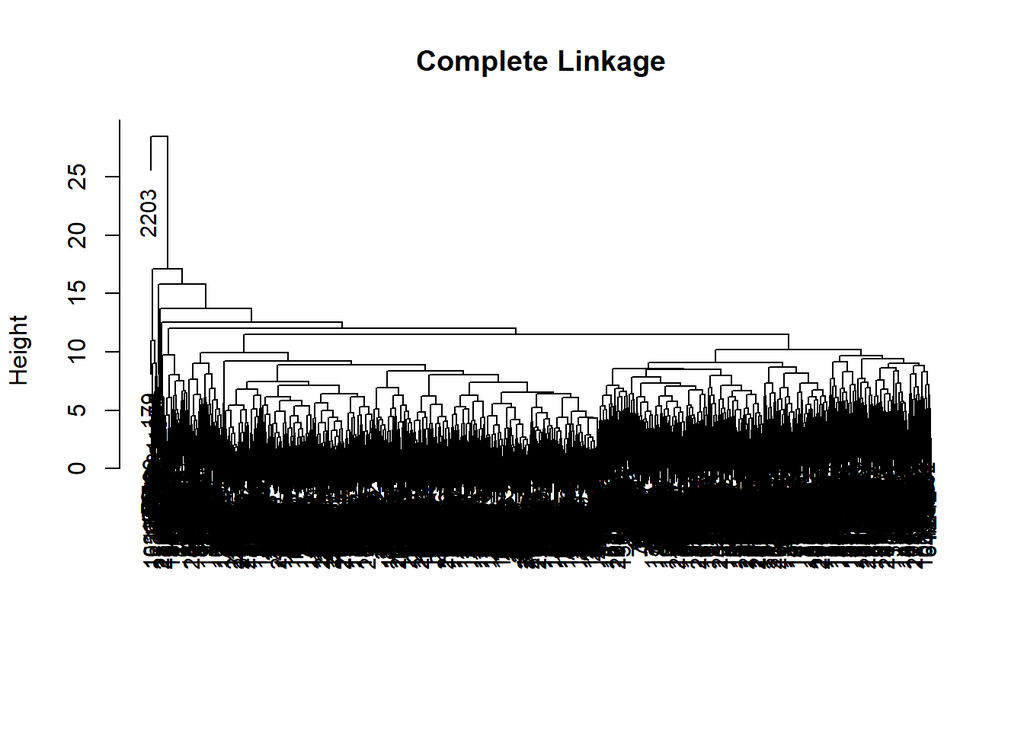

```r
x_dist <- dist(df_scale)
hc.complete <- hclust(dist(df_scale), method = "complete")
plot(hc.complete, main = "Complete Linkage",
    xlab = "", sub = "", cex = .9)
```

```r
library(ggdendro)
#p <- ggdendrogram(hc.complete, rotate = FALSE)
#ggplotly(p)
```

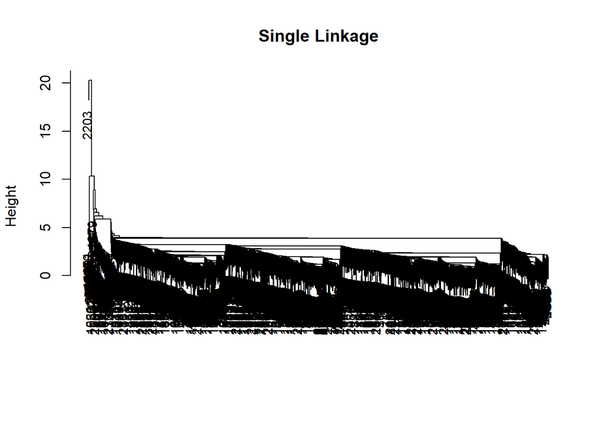

```r
hc.single <- hclust(dist(df_scale), method = "single")
plot(hc.single, main = "Single Linkage",
    xlab = "", sub = "", cex = .9)
```

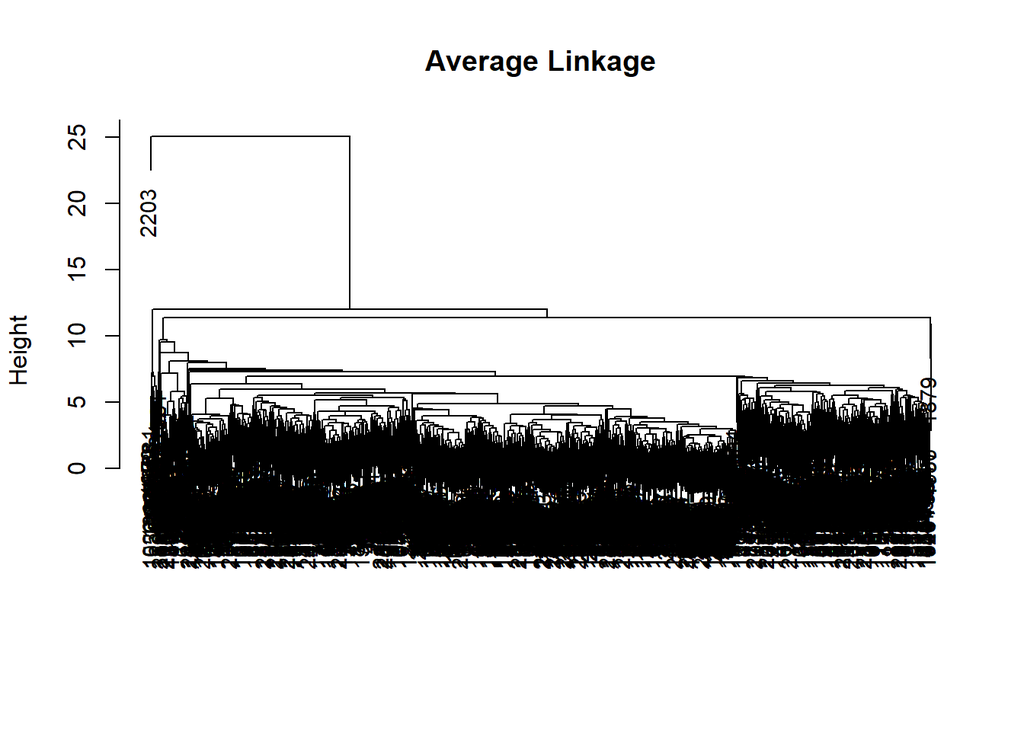

```r
hc.average <- hclust(dist(df_scale), method = "average")
plot(hc.average, main = "Average Linkage",
    xlab = "", sub = "", cex = .9)
```

Single linkage: closer observations but spread out clusters complete linkage: tighter observations but spread closely Average linkage: clusters are averaged to be closer We should be Complete or Averaged if we are to chose, while average linkage is still better between the two. # Additional grading criteria:

**G3.1** Was all random methods properly seeded? *(2 points)* The data was randomly spread so we used seed(786) to get the same output everytime.